# Multiple Regression: More than One Predictor

Dormann (2020), *Environmental Data Analysis* — Chapters 15 and 16

Emiel van Loon

today

## Where we are going

Every model so far had **one** predictor. Adding a second one is, in principle, just one more row in the coefficient table — but four things get complicated. At the end of this chapter you should…

- be able to **visualise** data and models with two predictors (panels, symbols, image/contour plots)
- know what a statistical **interaction** is, how it is coded, how you recognise it in a figure and in the output, and how to *read the equations* from a coefficient table
- recognise **collinearity** between predictors, know what it does to a model (VIF) and what to do about it
- understand **model selection**: the marginality principle, AIC vs BIC vs likelihood-ratio test, backward stepwise selection and best-subset regression — and their pitfalls

Skipped from Dormann: principal component analysis (15.3.1, 16.2.1), the two-way ANOVA by hand (15.4.1) and the matrix algebra (15.5). Practical 5 is a *reading* practical: you interpret output, you do not write code.

## One more predictor: what changes?

```r
ft_add <- glm(surv ~ age + sex, family = binomial, data = tit)
knitr::kable(coef(summary(ft_add)), digits = c(4, 4, 2, 6))
```

|  | Estimate | Std. Error | z value | Pr(>\|z\|) |
| --- | --- | --- | --- | --- |
| (Intercept) | 1.2354 | 0.1920 | 6.43 | 0.000000 |
| age | -0.0043 | 0.0052 | -0.82 | 0.413925 |
| sexmale | -2.4607 | 0.1523 | -16.16 | 0.000000 |

Survival of 1046 Titanic passengers, `survived ~ age + sex`. Each predictor gets its own maximum-likelihood estimate; a 42-year-old man survives with probability $\mathrm{logit}^{-1}(1.235 - 0.00425 \cdot 42 - 2.46) = 0.20$. Nothing new — except that four complications now arise:

1. **Visualising** — a figure has only two axes
2. **Interactions** — the effect of one predictor may depend on the other
3. **Collinearity** — predictors that carry the same information
4. **Model selection** — which of the many candidate models to report

“Multiple” regression = several predictors, one response. (*Multivariate* statistics means several *responses* — a different topic.)

## 1. Visualising two categorical predictors

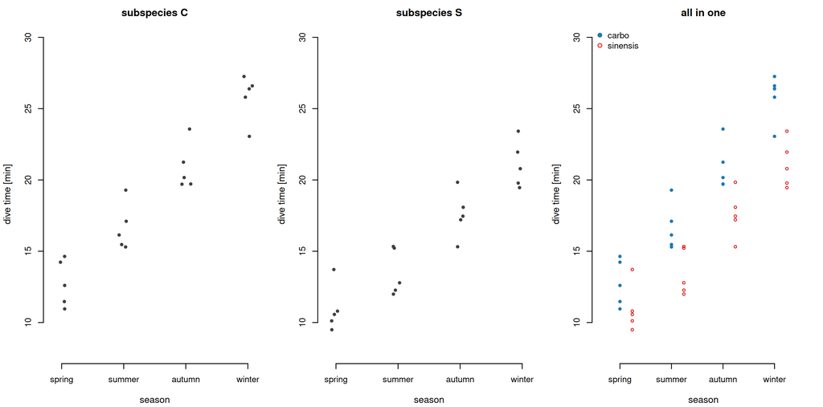

```r
parset(mfrow = c(1, 3), mar = c(4.2, 4.2, 2.4, 0.8), cex.main = 1.2)
for (sp in c("C", "S")) {
  d <- subset(cormorant, subspecies == sp)
  stripchart(divetime ~ season, data = d, vertical = TRUE, method = "jitter",
             jitter = 0.08, pch = 19, col = pal["dark"], ylim = c(8, 30),
             ylab = "dive time [min]", xlab = "season",
             main = paste("subspecies", sp))
}
stripchart(divetime ~ season, data = subset(cormorant, subspecies == "C"),
           vertical = TRUE, at = 1:4 - 0.12, pch = 19, col = pal["accent"],
           ylim = c(8, 30), ylab = "dive time [min]", xlab = "season",
           main = "all in one", xlim = c(0.5, 4.5))
stripchart(divetime ~ season, data = subset(cormorant, subspecies == "S"),
           vertical = TRUE, at = 1:4 + 0.12, pch = 1, col = pal["accent2"], add = TRUE)
legend("topleft", bty = "n", pch = c(19, 1), col = pal[c("accent", "accent2")],
       legend = c("carbo", "sinensis"))
```

Dive times of two European cormorant subspecies, *P. carbo carbo* (C) and *P. c. sinensis* (S), in four seasons (Dormann Figs 15.1, 15.2). **Panel plots** (left, middle) give a quick overview; an **all-in-one plot** (right) needs more work but takes less space. Either way we see the same thing: dive time increases over the year in *both* subspecies, and the smaller *sinensis* dives a little shorter. A continuous *x* works the same way — one panel, or one symbol, per level of the factor.

## Visualising binary data: smooth first

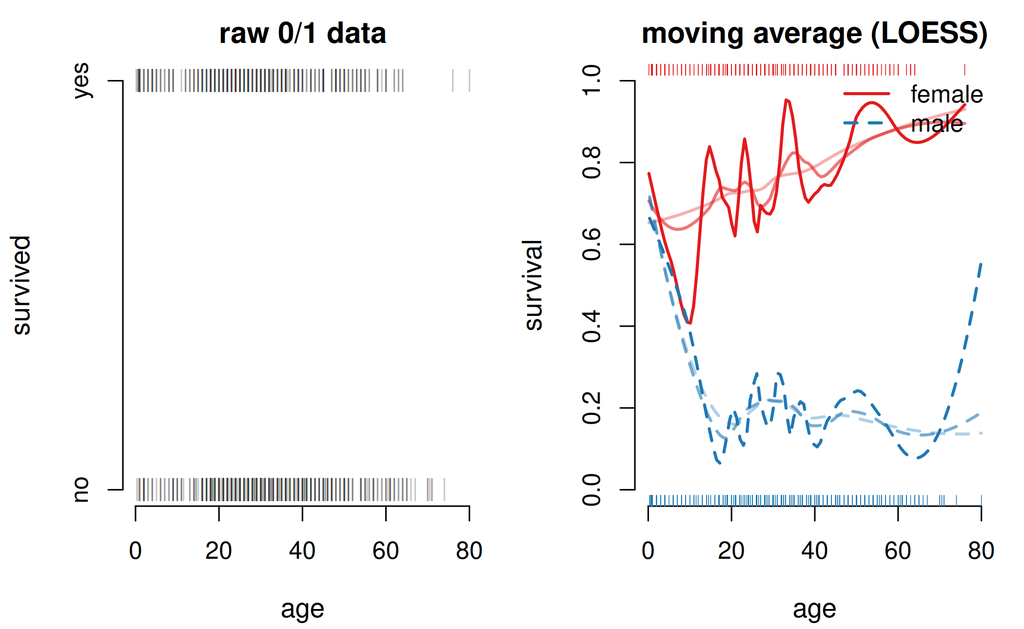

```r
parset(mfrow = c(1, 2))
plot(surv ~ age, data = tit, pch = "|", col = adjustcolor(pal["dark"], 0.3),
     yaxt = "n", ylab = "survived", xlab = "age", main = "raw 0/1 data")
axis(2, at = 0:1, labels = c("no", "yes"))
plot(NA, xlim = c(0, 80), ylim = c(0, 1), xlab = "age", ylab = "survival",
     main = "moving average (LOESS)")
for (s in c("female", "male")) {
  d <- subset(tit, sex == s)
  for (sp in c(0.2, 0.5, 0.75)) {
    lo <- loess(surv ~ age, data = d, span = sp)
    xs <- seq(min(d$age), max(d$age), length = 100)
    lines(xs, predict(lo, data.frame(age = xs)), lwd = 2,
          lty = ifelse(s == "female", 1, 2),
          col = adjustcolor(ifelse(s == "female", pal["accent2"], pal["accent"]),
                            c(1, 0.6, 0.35)[match(sp, c(0.2, 0.5, 0.75))]))
  }
  rug(d$age, side = ifelse(s == "female", 3, 1), col = ifelse(s == "female", pal["accent2"], pal["accent"]))
}
legend("topright", bty = "n", lwd = 2, lty = 1:2, col = pal[c("accent2", "accent")],
       legend = c("female", "male"))
```

Titanic survival against age (Dormann Figs 15.3–15.5). A panel or scatter plot of 0/1 data shows **nothing** (left). A **moving average** (LOESS: a local regression in a sliding window, span 0.2 / 0.5 / 0.75 from dark to light) makes the pattern visible: women survived at a high rate at every age, men’s survival dropped steeply with age. The window width is a choice — narrow traces the data, wide smooths it. Note the two curves are *not parallel*: that is an interaction.

## 2. Interactions: when one effect depends on the other

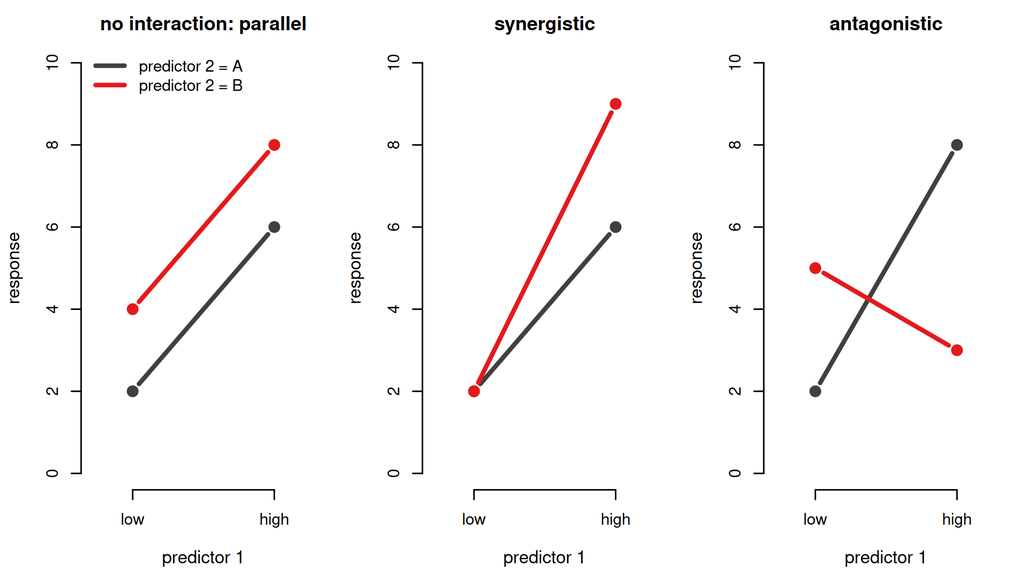

```r
parset(mfrow = c(1, 3), mar = c(4.2, 4.2, 2.4, 0.8), cex.main = 1.2)
x <- 1:2
draw <- function(a, b, main) {
  plot(NA, xlim = c(0.7, 2.3), ylim = c(0, 10), xaxt = "n", xlab = "predictor 1",
       ylab = "response", main = main)
  axis(1, at = 1:2, labels = c("low", "high"))
  lines(x, a, type = "b", pch = 19, lwd = 3, col = pal["dark"])
  lines(x, b, type = "b", pch = 19, lwd = 3, col = pal["accent2"])
}
draw(c(2, 6), c(4, 8), "no interaction: parallel")
legend("topleft", bty = "n", lwd = 3, col = pal[c("dark", "accent2")],
       legend = c("predictor 2 = A", "predictor 2 = B"))
draw(c(2, 6), c(2, 9), "synergistic")
draw(c(2, 8), c(5, 3), "antagonistic")
```

What does a plant need to grow? Water *and* light. More light helps — **but only if there is enough water**. That is a statistical interaction: the effect of one predictor depends on the value of the other (Dormann Fig. 15.6). In a figure you recognise it as lines with **different slopes**; parallel lines mean purely additive effects. Tropical trees grow because heat and rain come in the right combination; on the Titanic the effect of age depends on sex.

## How an interaction enters the model: multiply

| passenger | sex | age | sex × age |
| --- | --- | --- | --- |
| Miss Allen | female (0) | 29.0 | 0 |
| Master Allison | male (1) | 0.9 | 0.9 |
| Mrs Allison | female (0) | 25.0 | 0 |
| Mr Anderson | male (1) | 48.0 | 48.0 |

The factor is a **dummy** (0/1). Multiplying it with age gives a new variable that is *zero for all women* — an effect of age that applies to men only. `R` does this for you: `age * sex` means `age + sex + age:sex`.

```r
ft_int <- glm(surv ~ age * sex, family = binomial, data = tit)
knitr::kable(coef(summary(ft_int)), digits = c(4, 4, 2, 6))
```

|  | Estimate | Std. Error | z value | Pr(>\|z\|) |
| --- | --- | --- | --- | --- |
| (Intercept) | 0.4934 | 0.2542 | 1.94 | 0.052257 |
| age | 0.0225 | 0.0085 | 2.64 | 0.008342 |
| sexmale | -1.1541 | 0.3393 | -3.40 | 0.000671 |
| age:sexmale | -0.0463 | 0.0112 | -4.13 | 0.000037 |

- **age** = the slope of age *for women* (the reference level): +0.023 per year
- **sexmale** = the difference men − women *at age 0*
- **age:sexmale** = how much *steeper* the age slope is for men: −0.046, so men: 0.023 − 0.046 = **−0.024** per year

Two *continuous* predictors: the product is taken directly; **positive** = synergistic, **negative** = antagonistic (standardise first, or the larger one dominates). Beware: an unmodelled *quadratic* effect can masquerade as a significant interaction — test polynomials as well (Dormann footnote 4).

## Reading the ANOVA table: sequential, and the marginality principle

```r
a <- anova(ft_int, test = "Chisq")
knitr::kable(as.data.frame(a), digits = c(0, 1, 0, 1, 6))
```

|  | Df | Deviance | Resid. Df | Resid. Dev | Pr(>Chi) |
| --- | --- | --- | --- | --- | --- |
| NULL | NA | NA | 1045 | 1414.6 | NA |
| age | 1 | 3.2 | 1044 | 1411.4 | 0.071959 |
| sex | 1 | 310.0 | 1043 | 1101.3 | 0.000000 |
| age:sex | 1 | 17.9 | 1042 | 1083.4 | 0.000023 |

**Do not conclude “age does not matter”.** The significant interaction says that the main effects *alone* do not describe the pattern: the sexes differ strongly, but *not* among young children. Once an interaction is in the model, its **main effects must stay** — even if not significant — because the interaction *contains* them (Nelder’s **marginality principle**). And do not rank importance by the deviance column: with correlated predictors the order of the terms changes the numbers (but never the residual deviance).

## Two categorical predictors: cormorants, additive vs interaction

```r
fc_add <- glm(divetime ~ season + subspecies, family = gaussian, data = cormorant)
fc_int <- glm(divetime ~ season * subspecies, family = gaussian, data = cormorant)
ca <- coef(summary(fc_add))[, 1:2]
a  <- as.data.frame(anova(fc_int, test = "F"))[-1, c(1, 2, 5, 6)]
knitr::kable(ca, digits = 2)
```

|  | Estimate | Std. Error |
| --- | --- | --- |
| (Intercept) | 13.49 | 0.58 |
| seasonsummer | 3.23 | 0.74 |
| seasonautumn | 7.37 | 0.74 |
| seasonwinter | 11.59 | 0.74 |
| subspeciesS | -3.26 | 0.52 |

```r
knitr::kable(a, digits = c(0, 1, 1, 3))
```

|  | Df | Deviance | F | Pr(>F) |
| --- | --- | --- | --- | --- |
| season | 3 | 759.8 | 95.3 | 0.000 |
| subspecies | 1 | 106.0 | 39.9 | 0.000 |
| season:subspecies | 3 | 10.6 | 1.3 | 0.284 |

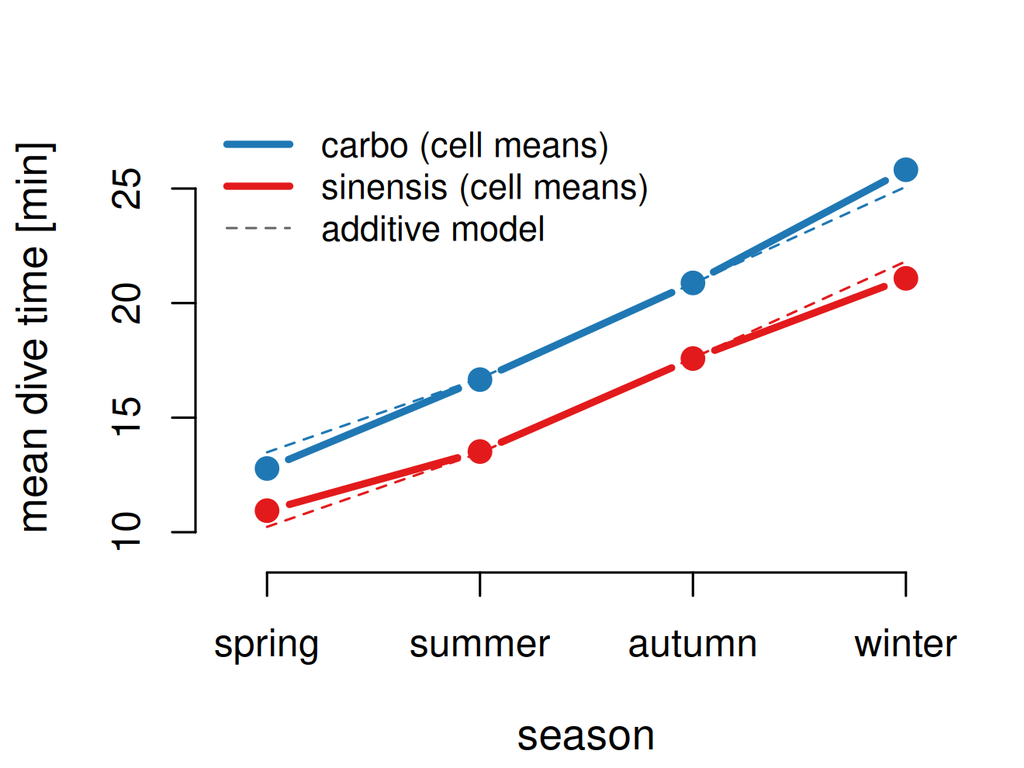

```r
parset()
m <- tapply(cormorant$divetime, list(cormorant$season, cormorant$subspecies), mean)
plot(1:4, m[, "C"], type = "b", pch = 19, lwd = 3, col = pal["accent"], xaxt = "n",
     ylim = c(9, 28), xlab = "season", ylab = "mean dive time [min]", xlim = c(0.8, 4.2))
lines(1:4, m[, "S"], type = "b", pch = 19, lwd = 3, col = pal["accent2"])
pa <- predict(fc_add, newdata = expand.grid(season = levels(cormorant$season), subspecies = c("C", "S")))
lines(1:4, pa[1:4], lty = 2, col = pal["accent"]); lines(1:4, pa[5:8], lty = 2, col = pal["accent2"])
axis(1, at = 1:4, labels = levels(cormorant$season))
legend("topleft", bty = "n", lwd = c(3, 3, 1), lty = c(1, 1, 2),
       col = c(pal["accent"], pal["accent2"], "grey40"),
       legend = c("carbo (cell means)", "sinensis (cell means)", "additive model"), cex = 0.9)
```

## Continuous + categorical: the four models of an ANCOVA

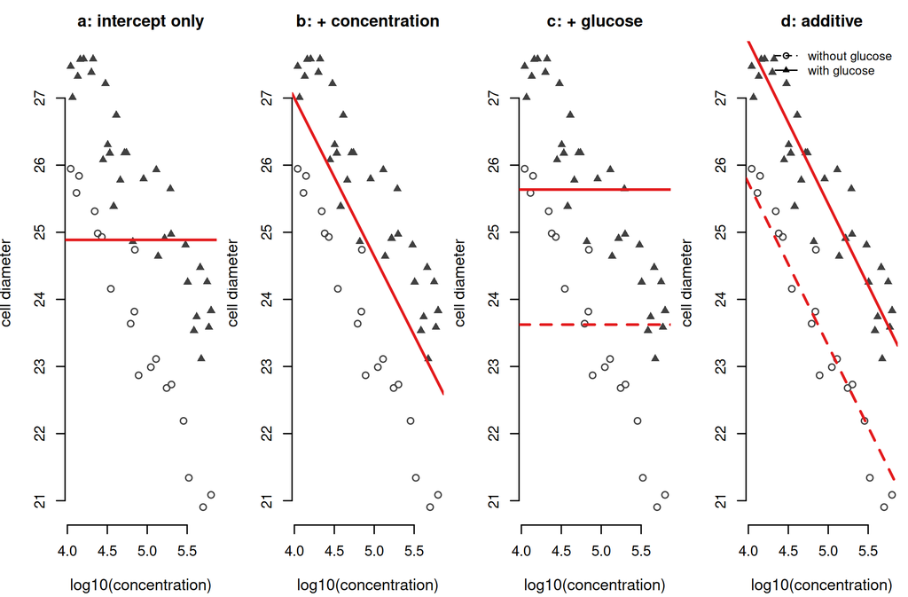

```r
parset(mfrow = c(1, 4), mar = c(4.2, 3.8, 2.4, 0.6), cex.main = 1.15)
tet$lconc <- log10(tet$conc)
pchs <- c(No = 1, Yes = 17)
base <- function(main) {
  plot(diameter ~ lconc, data = tet, pch = pchs[as.character(glucose)],
       col = pal["dark"], xlab = "log10(concentration)", ylab = "cell diameter", main = main)
}
base("a: intercept only"); abline(h = mean(tet$diameter), lwd = 2, col = pal["accent2"])
base("b: + concentration"); abline(lm(diameter ~ lconc, tet), lwd = 2, col = pal["accent2"])
base("c: + glucose"); cg <- coef(lm(diameter ~ glucose, tet))
abline(h = cg[1], lwd = 2, lty = 2, col = pal["accent2"]); abline(h = sum(cg), lwd = 2, col = pal["accent2"])
base("d: additive"); ca <- coef(lm(diameter ~ lconc + glucose, tet))
abline(ca[1], ca[2], lwd = 2, lty = 2, col = pal["accent2"]); abline(ca[1] + ca[3], ca[2], lwd = 2, col = pal["accent2"])
legend("topright", bty = "n", pch = c(1, 17), lty = c(2, 1), legend = c("without glucose", "with glucose"), cex = 0.85)
```

Diameter of *Tetrahymena* cells against culture density, with and without added glucose (Dormann Fig. 16.4; data after Dalgaard 2002). A model with a continuous and a categorical predictor is traditionally called **ANCOVA** — “analysis of covariance” — only for nostalgic reasons: it is just a GLM. (**a**) one mean; (**b**) one regression line; (**c**) two means; (**d**) the additive model `diameter ~ log10(conc) + glucose`: **two parallel lines** — the factor shifts the intercept, the slope is shared.

## The fifth model: one slope per group

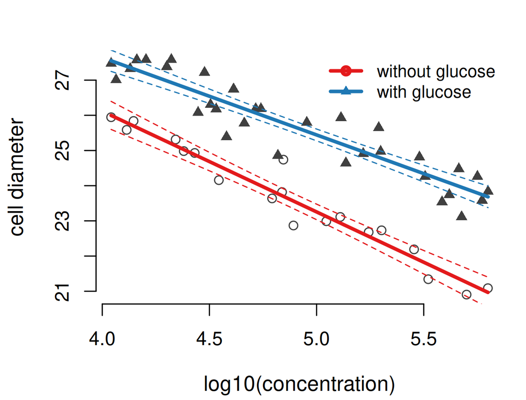

```r
ft <- lm(diameter ~ lconc * glucose, data = tet)
parset()
plot(diameter ~ lconc, data = tet, pch = pchs[as.character(glucose)], col = pal["dark"],
     xlab = "log10(concentration)", ylab = "cell diameter")
for (gl in c("No", "Yes")) {
  d <- subset(tet, glucose == gl)
  xs <- seq(min(d$lconc), max(d$lconc), length = 50)
  pr <- predict(ft, newdata = data.frame(lconc = xs, glucose = gl), interval = "confidence")
  matlines(xs, pr, lty = c(1, 2, 2), lwd = c(3, 1, 1),
           col = ifelse(gl == "Yes", pal["accent"], pal["accent2"]))
}
legend("topright", bty = "n", pch = c(1, 17), lwd = 3, col = pal[c("accent2", "accent")],
       legend = c("without glucose", "with glucose"), cex = 0.9)
```

```r
knitr::kable(coef(summary(ft)), digits = c(3, 3, 2, 4))
```

|  | Estimate | Std. Error | t value | Pr(>\|t\|) |
| --- | --- | --- | --- | --- |
| (Intercept) | 37.559 | 0.988 | 38.03 | 0.0000 |
| lconc | -2.861 | 0.202 | -14.19 | 0.0000 |
| glucoseYes | -1.122 | 1.219 | -0.92 | 0.3618 |
| lconc:glucoseYes | 0.662 | 0.248 | 2.67 | 0.0104 |

Read the two lines straight from the table:

- without glucose (reference): $\hat y = 37.6 - 2.86 \cdot \log_{10}(\mathrm{conc})$
- with glucose: intercept **and** slope get their extra term: $\hat y = (37.6 - 1.1) + (-2.86 + 0.66) \cdot \log_{10}(\mathrm{conc})$

The interaction is significant (*P* = 0.01): the **slopes differ**. The glucose main effect (*P* = 0.36) is the intercept difference *at log10(conc) = 0* — far outside the data, and it must stay in the model anyway.

Dormann Figs 16.3 / 16.5: lines only over the data range, 95% bands via `predict(..., interval = "confidence")` and `matlines()`. “Glucose does have an effect, but it is only detectable if we take the cell concentration into account.”

## Two continuous predictors: C3 grasses in North America

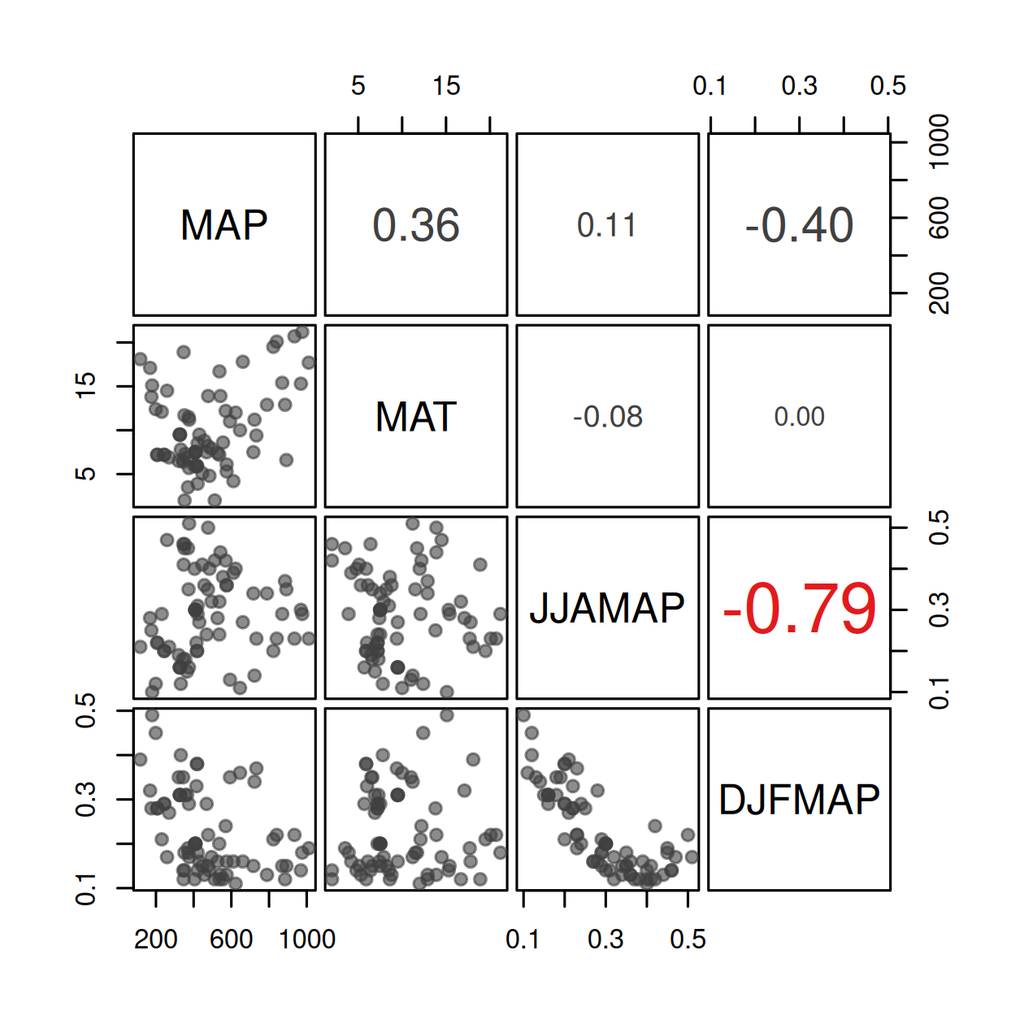

```r
panel.cor <- function(x, y, ...) {
  usr <- par("usr"); on.exit(par(usr)); par(usr = c(0, 1, 0, 1))
  r <- cor(x, y)
  text(0.5, 0.5, sprintf("%.2f", r), cex = 1 + 2 * abs(r),
       col = ifelse(abs(r) > 0.7, pal["accent2"], pal["dark"]))
}
pairs(paruelo[, c("MAP", "MAT", "JJAMAP", "DJFMAP")], pch = 19,
      col = adjustcolor(pal["dark"], 0.6), upper.panel = panel.cor, gap = 0.3)
```

Proportion of C3 grasses (√-transformed) at 73 sites (Paruelo & Lauenroth 1996) against mean annual precipitation (MAP), temperature (MAT) and the fraction of summer (JJAMAP) and winter rain (DJFMAP).

**Step 0: check the predictors.** Summer and winter rain are strongly negatively correlated (*r* = −0.79 > 0.7): keep only one — JJAMAP, because growth happens in summer.

**Step 1: the full model** `sqC3 ~ MAP * MAT * JJAMAP` — 3 main effects, 3 two-way and 1 three-way interaction.

```r
fp_full  <- lm(sqC3 ~ MAP * MAT * JJAMAP, data = paruelo)
fp_final <- lm(sqC3 ~ MAP + MAT * JJAMAP, data = paruelo)
a <- anova(fp_full)
knitr::kable(as.data.frame(a)[-8, c(1, 2, 4, 5)], digits = c(0, 3, 2, 4))
```

|  | Df | Sum Sq | F value | Pr(>F) |
| --- | --- | --- | --- | --- |
| MAP | 1 | 0.000 | 0.00 | 0.9859 |
| MAT | 1 | 1.962 | 35.78 | 0.0000 |
| JJAMAP | 1 | 0.100 | 1.83 | 0.1808 |
| MAP:MAT | 1 | 0.030 | 0.54 | 0.4647 |
| MAP:JJAMAP | 1 | 0.016 | 0.29 | 0.5928 |
| MAT:JJAMAP | 1 | 0.282 | 5.14 | 0.0267 |
| MAP:MAT:JJAMAP | 1 | 0.000 | 0.00 | 0.9554 |

## Visualising an interaction of two continuous predictors

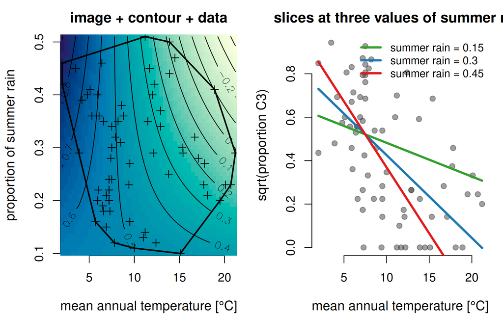

```r
parset(mfrow = c(1, 2), mar = c(4.2, 4.2, 2.4, 1))
temperature <- seq(min(paruelo$MAT), max(paruelo$MAT), length = 50)
summerrain  <- seq(min(paruelo$JJAMAP), max(paruelo$JJAMAP), length = 50)
z <- outer(temperature, summerrain, function(X, Y)
  predict(fp_final, newdata = data.frame(MAP = mean(paruelo$MAP), MAT = X, JJAMAP = Y)))
image(temperature, summerrain, z, col = hcl.colors(50, "YlGnBu", rev = TRUE),
      xlab = "mean annual temperature [°C]", ylab = "proportion of summer rain",
      main = "image + contour + data")
contour(temperature, summerrain, z, add = TRUE, labcex = 0.9)
points(paruelo$MAT, paruelo$JJAMAP, pch = 3)
ch <- chull(cbind(paruelo$MAT, paruelo$JJAMAP))
polygon(cbind(paruelo$MAT, paruelo$JJAMAP)[ch, ], lwd = 2)
plot(sqC3 ~ MAT, data = paruelo, pch = 19, col = adjustcolor(pal["dark"], 0.5),
     xlab = "mean annual temperature [°C]", ylab = "sqrt(proportion C3)",
     main = "slices at three values of summer rain")
jj <- c(0.15, 0.30, 0.45); cols <- c(pal["accent3"], pal["accent"], pal["accent2"])
for (i in 1:3)
  lines(temperature, predict(fp_final, newdata = data.frame(MAP = mean(paruelo$MAP),
        MAT = temperature, JJAMAP = jj[i])), lwd = 3, col = cols[i])
legend("topright", bty = "n", lwd = 3, col = cols, legend = paste("summer rain =", jj), cex = 0.9)
```

Dormann Figs 16.7–16.9. Two predictors plus a response need a **surface**: `outer()` evaluates `predict()` on a grid, `image()` colours it, `contour()` labels it — here at the mean MAP. The effect of temperature is steepest where summer rain is high: a continuous change of slope, the interaction. **Always add the data points** and their convex hull: the empty corners (hot *and* summer-wet) contain no observations, and predictions there have no basis. With every extra dimension this “curse of dimensionality” gets worse. Slices (right) are the poor man’s effect plot.

## 3. Collinearity: two predictors that say the same thing

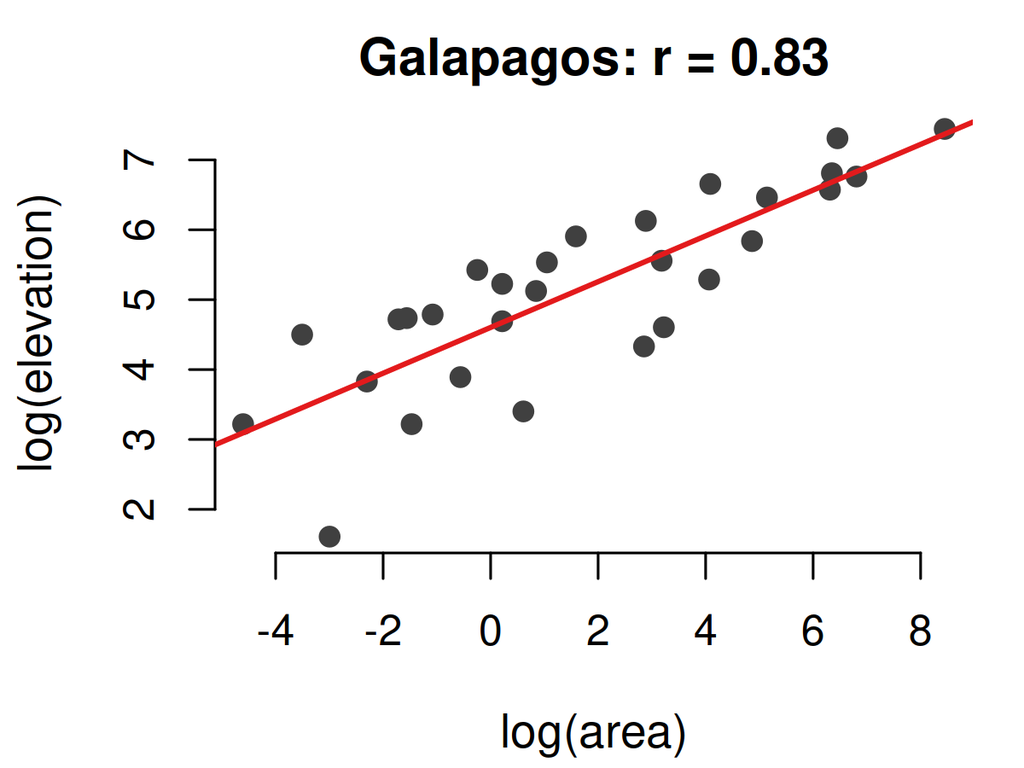

```r
parset()
plot(lElev ~ lArea, data = g, pch = 19, col = pal["dark"], xlab = "log(area)", ylab = "log(elevation)",
     main = sprintf("Galapagos: r = %.2f", cor(g$lArea, g$lElev)))
abline(lm(lElev ~ lArea, g), lwd = 2, col = pal["accent2"])
```

```r
m_area <- glm.nb(Species ~ lArea, data = g)
m_elev <- glm.nb(Species ~ lElev, data = g)
m_both <- glm.nb(Species ~ lArea + lElev, data = g)
tab <- rbind(
  `Species ~ lArea`         = c(coef(summary(m_area))["lArea", 1:2], NA, NA),
  `Species ~ lElev`         = c(NA, NA, coef(summary(m_elev))["lElev", 1:2]),
  `Species ~ lArea + lElev` = c(coef(summary(m_both))["lArea", 1:2], coef(summary(m_both))["lElev", 1:2]))
colnames(tab) <- c("lArea", "SE", "lElev", "SE ")
knitr::kable(tab, digits = 3, format.args = list(nsmall = 3)) |> gsub(pattern = "NA", replacement = "")
```

|  | lArea | SE | lElev | SE |
| --- | --- | --- | --- | --- |
| Species ~ lArea | 0.367 | 0.036 |  |  |
| Species ~ lElev |  |  | 0.761 | 0.127 |
| Species ~ lArea + lElev | 0.389 | 0.065 | -0.065 | 0.165 |

VIF of the two-predictor model: 3.3 — the variance of each coefficient is 3.3 × what it would be with uncorrelated predictors (SE of `lArea`: 0.036 → 0.065).

Diagnose **before** modelling: `cor()` / `pairs()` — |*r*| < 0.7 is safe. After modelling: `car::vif()` — values above 10 (Appalachian soils: 65,655!) mean a predictor has to go. The remedy in this course: keep one representative of each correlated group (Dormann’s PCA and cluster analysis are the alternatives).

## 4. Model selection: how many models, and which one?

**The full model** contains every predictor you consider reasonable, with interactions (and polynomials). Rule of thumb: **5–10 data points per model term** (Harrell) — 100 observations allow ~10 terms; for 0/1 data count the rarer outcome.

With 14 terms there are $2^{14}$ = 16 384 sub-models. Three strategies:

- **backward stepwise**: start full, drop the term whose removal improves the criterion most, repeat (`step()`)
- **forward stepwise**: start empty, add — *strongly discouraged*: a predictor that only matters in an interaction never gets in
- **best subset**: fit *all* sub-models and rank them (`MuMIn::dredge()`)

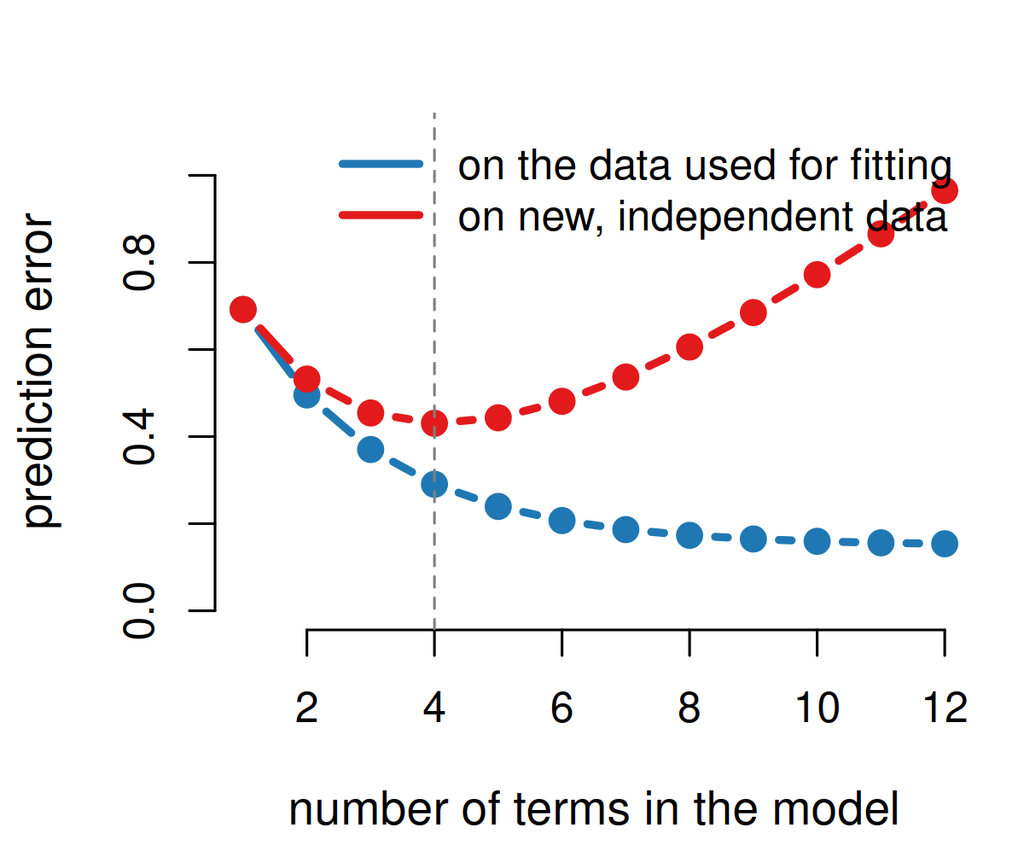

```r
parset()
k <- 1:12
train <- 1 - 0.85 * (1 - exp(-0.45 * k))
test  <- train + 0.02 * k^1.5 - 0.02
plot(k, train, type = "b", pch = 19, lwd = 3, col = pal["accent"], ylim = c(0, 1.1),
     xlab = "number of terms in the model", ylab = "prediction error")
lines(k, test, type = "b", pch = 19, lwd = 3, col = pal["accent2"])
abline(v = k[which.min(test)], lty = 2, col = "grey50")
legend("topright", bty = "n", lwd = 3, col = pal[c("accent", "accent2")],
       legend = c("on the data used for fitting", "on new, independent data"))
```

Why not always keep the full model? It fits *these* data best and its estimates are unbiased — but it **traces the data set**. The **variance–bias trade-off** (schematic): with more terms the fit to the training data always improves, the error on new data first drops and then rises. Information criteria — AIC, BIC — balance fit (log-likelihood) against complexity (number of parameters) to find that minimum; BIC penalises harder and prefers smaller models. And every stepwise removal is a test, so selection distorts the *p*-values that survive.

## Comparing two candidate models: AIC, BIC and the LR test

```r
lrt <- anova(ft_add, ft_int, test = "Chisq")
tab <- data.frame(
  model = c("1: survived ~ age + sex", "2: survived ~ age * sex"),
  df = c(3, 4), `log-likelihood` = c(logLik(ft_add), logLik(ft_int)),
  AIC = AIC(ft_add, ft_int)$AIC, BIC = BIC(ft_add, ft_int)$BIC,
  `LR test: deviance` = c(NA, lrt$Deviance[2]), `P (chi-sq)` = c(NA, lrt$`Pr(>Chi)`[2]),
  check.names = FALSE)
knitr::kable(tab, digits = c(0, 0, 1, 1, 1, 1, 7))
```

| model | df | log-likelihood | AIC | BIC | LR test: deviance | P (chi-sq) |
| --- | --- | --- | --- | --- | --- | --- |
| 1: survived ~ age + sex | 3 | -550.7 | 1107.3 | 1122.2 | NA | NA |
| 2: survived ~ age * sex | 4 | -541.7 | 1091.4 | 1111.2 | 17.9 | 2.32e-05 |

Dormann’s Table 15.1: two ways to compare the additive and the interaction model of Titanic survival.

- **AIC / BIC**: lower is better; a difference of **≥ 2 units is substantial** (they live on the log-likelihood scale: 3.6 units ≈ 37-fold likelihood). Model 2 wins by 16 (AIC) and 11 (BIC) units.
- **Likelihood-ratio test** (`anova(m1, m2, test = "Chisq")`): only for *nested* models; the deviance difference is $\chi^2$ with df = difference in parameters. Here 17.9 on 1 df, *P* < 0.0001.
- For quasi-models there is no likelihood, hence no AIC: use `test = "F"`.

The criteria do not always agree — on the Titanic test data the simpler model even had the better $R^2$. Which criterion, you decide **beforehand**; AIC (or BIC) is currently the standard.

## Backward stepwise selection with `step()`: reading the output

````r
ft_full <- glm(surv ~ sex * age * passengerClass, family = binomial, data = tit)
out <- capture.output(sB <- step(ft_full, k = log(nrow(tit)), steps = 1))
cat("```\n", paste(out[1:6], collapse = "\n"), "\n```\n", sep = "")
````

```
Start:  AIC=999.41
surv ~ sex * age * passengerClass

                         Df Deviance    AIC
- sex:age:passengerClass  2   917.84 987.37
<none>                        915.98 999.41
```

```r
sBIC <- step(ft_full, k = log(nrow(tit)), trace = 0)
sAIC <- step(ft_full, trace = 0)
```

```r
tab <- data.frame(criterion = c("full model", "backward by AIC", "backward by BIC"),
                  `final model` = c(deparse(formula(ft_full)[[3]]),
                                    paste(deparse(formula(sAIC)[[3]]), collapse = ""),
                                    paste(deparse(formula(sBIC)[[3]]), collapse = "")),
                  terms = c(8, length(attr(terms(sAIC), "term.labels")), length(attr(terms(sBIC), "term.labels"))),
                  AIC = AIC(ft_full, sAIC, sBIC)$AIC, BIC = BIC(ft_full, sAIC, sBIC)$BIC, check.names = FALSE)
knitr::kable(tab, digits = c(0, 0, 0, 1, 1))
```

[output not shown]

AIC keeps all two-way interactions; BIC ends with `sex:passengerClass` only. Dormann’s warning: stepwise selection looks **one step ahead** — a removal that only pays off together with a second one is never found, so an AIC-driven `step()` can stop at a model with a *worse* AIC than a BIC-selected one. Not a panacea (Austin & Tu 2004); it gets more reliable with more data per term.

## Best-subset regression: fit them all, then weigh

```r
m_all <- glm.nb(Species ~ lArea + lElev + lNear + lAdj, data = g, na.action = na.fail)
dm <- dredge(m_all, rank = "AIC", trace = 0)
```

```
## Fixed term is "(Intercept)"
```

```r
d <- as.data.frame(subset(dm, delta < 2, recalc.weights = FALSE))
d <- d[, c("lArea", "lElev", "lNear", "lAdj", "df", "AIC", "delta", "weight")]
d[, 1:4] <- lapply(d[, 1:4], function(v) ifelse(is.na(v), "", sprintf("%.3f", v)))
d$AIC <- round(d$AIC, 1); d$delta <- round(d$delta, 2); d$weight <- round(d$weight, 2)
rownames(d) <- NULL
knitr::kable(d, digits = c(0, 0, 0, 0, 0, 1, 2, 2))
```

| lArea | lElev | lNear | lAdj | df | AIC | delta | weight |
| --- | --- | --- | --- | --- | --- | --- | --- |
| 0.376 |  | -0.123 |  | 4 | 273.4 | 0.00 | 0.28 |
| 0.367 |  |  |  | 3 | 274.0 | 0.61 | 0.21 |
| 0.375 |  | -0.130 | -0.030 | 5 | 274.7 | 1.29 | 0.15 |
| 0.371 | 0.017 | -0.125 |  | 5 | 275.4 | 1.99 | 0.10 |

`MuMIn::dredge()` fits all $2^4$ = 16 negative-binomial models of Galapagos plant richness (`na.action = na.fail` makes every model use the same rows). Shown: the models within 2 AIC units of the best.

Dredging is criticised as “fishing”: afterwards we act as if we had planned this one model, so its **p-values and confidence intervals are wrong** (point predictions are fine). Whatever you do — say what you did.

## What you will do in practical 5

No code to write — you **read and interpret** output, as you would in a paper:

1. **Two factors** (`birdmalariaO`): reconstruct the four group means from the coefficients of `Sex * mmal`; read a sequential ANOVA table; additive or interaction model?
2. **ANCOVA** (`regrowth`): why the boxplot and the coefficient disagree about grazing; two parallel lines from one table; why the order of terms changes the deviance
3. **Continuous × factor interaction** (`wells`, quasi-binomial): two logit equations; non-significant main effects that must stay; *F* instead of χ²
4. **Negative binomial with interaction** (`RIKZdat`): slopes per exposure class, LR test with 2 df, AIC ranking of four models, back-transforming with `exp()`
5. **Collinearity** (`gala`): |*r*| > 0.7, VIF, what happens to elevation once area is in the model
6. **Two continuous predictors** (`loyn`): slopes at grazing 1 and 5, image/contour plot and the empty corners
7. **Model selection** (`loyn`): a `step()` table, AIC vs BIC results, a `dredge()` table with delta and weight — and the caveat about the p-values

## Take-home messages

1. A second predictor is one more coefficient — but brings four problems: **visualising, interactions, collinearity, model selection**.
2. Visualise with panels or symbols; smooth binary data (LOESS); for two continuous predictors draw the surface (`outer` → `image` + `contour`) **with the data points on it**.
3. An **interaction** = the effect of one predictor depends on the other: non-parallel lines; coded as the *product*; the coefficient is the change in slope. Main effects then refer to the *reference level* / *x = 0* and must **stay in the model** (marginality).
4. Read the fitted equations from the table: reference group = intercept + slope; other groups add their extra intercept **and** extra slope.
5. `anova()` of one model is **sequential** — order matters when predictors are correlated; `anova(m1, m2)` compares two nested models.
6. **Collinearity** (|*r*| > 0.7, VIF > 10) makes effects unattributable and estimates unstable: check the predictors *before* modelling, keep one per group.
7. Compare candidate models by **AIC/BIC** (≥ 2 units) or an LR test; simplify **backwards** (`step()`, BIC for small *n*) or search all subsets (`dredge()`, weights); never forward. Selected models have optimistic *p*-values — say so.

Dormann, C. F. (2020). *Environmental Data Analysis: An Introduction with Examples in R*, Chapters 15 and 16. Springer. Data: `carData::TitanicSurvival`, `ISwR::hellung`, Paruelo & Lauenroth (1996) via Quinn & Keough (2002), `qsbsdata::gala`.